# Optimal Treatment Analysis

## Outcome Variable

**Outcome Variable:** ever_wasted

## Predictor Variables

**Intervention Variable:** month

**Adjustment Set:**

unadjusted

## Stratifying Variables

The analysis was stratified on these variable(s):

- agecat
- studyid
- country

## Data Summary

| agecat | studyid | country | month | ever_wasted | n_cell | n |
| --- | --- | --- | --- | --- | --- | --- |
| 0-24 months (no birth wast) | ki0047075b-MAL-ED | BANGLADESH | 1 | 0 | 18 | 261 |
| 0-24 months (no birth wast) | ki0047075b-MAL-ED | BANGLADESH | 1 | 1 | 3 | 261 |
| 0-24 months (no birth wast) | ki0047075b-MAL-ED | BANGLADESH | 2 | 0 | 17 | 261 |
| 0-24 months (no birth wast) | ki0047075b-MAL-ED | BANGLADESH | 2 | 1 | 7 | 261 |
| 0-24 months (no birth wast) | ki0047075b-MAL-ED | BANGLADESH | 3 | 0 | 14 | 261 |
| 0-24 months (no birth wast) | ki0047075b-MAL-ED | BANGLADESH | 3 | 1 | 12 | 261 |
| 0-24 months (no birth wast) | ki0047075b-MAL-ED | BANGLADESH | 4 | 0 | 18 | 261 |
| 0-24 months (no birth wast) | ki0047075b-MAL-ED | BANGLADESH | 4 | 1 | 4 | 261 |
| 0-24 months (no birth wast) | ki0047075b-MAL-ED | BANGLADESH | 5 | 0 | 16 | 261 |
| 0-24 months (no birth wast) | ki0047075b-MAL-ED | BANGLADESH | 5 | 1 | 6 | 261 |
| 0-24 months (no birth wast) | ki0047075b-MAL-ED | BANGLADESH | 6 | 0 | 7 | 261 |
| 0-24 months (no birth wast) | ki0047075b-MAL-ED | BANGLADESH | 6 | 1 | 2 | 261 |
| 0-24 months (no birth wast) | ki0047075b-MAL-ED | BANGLADESH | 7 | 0 | 16 | 261 |
| 0-24 months (no birth wast) | ki0047075b-MAL-ED | BANGLADESH | 7 | 1 | 6 | 261 |
| 0-24 months (no birth wast) | ki0047075b-MAL-ED | BANGLADESH | 8 | 0 | 24 | 261 |
| 0-24 months (no birth wast) | ki0047075b-MAL-ED | BANGLADESH | 8 | 1 | 1 | 261 |
| 0-24 months (no birth wast) | ki0047075b-MAL-ED | BANGLADESH | 9 | 0 | 13 | 261 |
| 0-24 months (no birth wast) | ki0047075b-MAL-ED | BANGLADESH | 9 | 1 | 10 | 261 |
| 0-24 months (no birth wast) | ki0047075b-MAL-ED | BANGLADESH | 10 | 0 | 20 | 261 |
| 0-24 months (no birth wast) | ki0047075b-MAL-ED | BANGLADESH | 10 | 1 | 3 | 261 |
| 0-24 months (no birth wast) | ki0047075b-MAL-ED | BANGLADESH | 11 | 0 | 15 | 261 |
| 0-24 months (no birth wast) | ki0047075b-MAL-ED | BANGLADESH | 11 | 1 | 2 | 261 |
| 0-24 months (no birth wast) | ki0047075b-MAL-ED | BANGLADESH | 12 | 0 | 25 | 261 |
| 0-24 months (no birth wast) | ki0047075b-MAL-ED | BANGLADESH | 12 | 1 | 2 | 261 |
| 0-24 months (no birth wast) | ki0047075b-MAL-ED | BRAZIL | 1 | 0 | 13 | 229 |
| 0-24 months (no birth wast) | ki0047075b-MAL-ED | BRAZIL | 1 | 1 | 0 | 229 |
| 0-24 months (no birth wast) | ki0047075b-MAL-ED | BRAZIL | 2 | 0 | 24 | 229 |
| 0-24 months (no birth wast) | ki0047075b-MAL-ED | BRAZIL | 2 | 1 | 2 | 229 |
| 0-24 months (no birth wast) | ki0047075b-MAL-ED | BRAZIL | 3 | 0 | 20 | 229 |
| 0-24 months (no birth wast) | ki0047075b-MAL-ED | BRAZIL | 3 | 1 | 1 | 229 |

[output cut: 1962 more lines]

The following strata were considered:

- agecat: 0-24 months (no birth wast), studyid: ki0047075b-MAL-ED, country: BANGLADESH
- agecat: 0-24 months (no birth wast), studyid: ki0047075b-MAL-ED, country: BRAZIL
- agecat: 0-24 months (no birth wast), studyid: ki0047075b-MAL-ED, country: INDIA
- agecat: 0-24 months (no birth wast), studyid: ki0047075b-MAL-ED, country: NEPAL
- agecat: 0-24 months (no birth wast), studyid: ki0047075b-MAL-ED, country: PERU
- agecat: 0-24 months (no birth wast), studyid: ki0047075b-MAL-ED, country: SOUTH AFRICA
- agecat: 0-24 months (no birth wast), studyid: ki0047075b-MAL-ED, country: TANZANIA, UNITED REPUBLIC OF
- agecat: 0-24 months (no birth wast), studyid: ki1000108-CMC-V-BCS-2002, country: INDIA
- agecat: 0-24 months (no birth wast), studyid: ki1000108-IRC, country: INDIA
- agecat: 0-24 months (no birth wast), studyid: ki1000109-EE, country: PAKISTAN
- agecat: 0-24 months (no birth wast), studyid: ki1000109-ResPak, country: PAKISTAN
- agecat: 0-24 months (no birth wast), studyid: ki1000304b-SAS-CompFeed, country: INDIA
- agecat: 0-24 months (no birth wast), studyid: ki1000304b-SAS-FoodSuppl, country: INDIA
- agecat: 0-24 months (no birth wast), studyid: ki1017093-NIH-Birth, country: BANGLADESH
- agecat: 0-24 months (no birth wast), studyid: ki1066203-TanzaniaChild2, country: TANZANIA, UNITED REPUBLIC OF
- agecat: 0-24 months (no birth wast), studyid: ki1112895-Guatemala BSC, country: GUATEMALA
- agecat: 0-24 months (no birth wast), studyid: ki1112895-iLiNS-Zinc, country: BURKINA FASO
- agecat: 0-24 months (no birth wast), studyid: ki1113344-GMS-Nepal, country: NEPAL
- agecat: 0-24 months (no birth wast), studyid: ki1114097-CMIN, country: BANGLADESH
- agecat: 0-24 months (no birth wast), studyid: ki1114097-CMIN, country: BRAZIL
- agecat: 0-24 months (no birth wast), studyid: ki1114097-CMIN, country: GUINEA-BISSAU
- agecat: 0-24 months (no birth wast), studyid: ki1114097-CMIN, country: PERU
- agecat: 0-24 months (no birth wast), studyid: ki1114097-CONTENT, country: PERU
- agecat: 0-24 months (no birth wast), studyid: ki1119695-PROBIT, country: BELARUS
- agecat: 0-24 months (no birth wast), studyid: ki1126311-ZVITAMBO, country: ZIMBABWE
- agecat: 0-24 months (no birth wast), studyid: ki1148112-LCNI-5, country: MALAWI
- agecat: 0-24 months (no birth wast), studyid: kiGH5241-JiVitA-3, country: BANGLADESH
- agecat: 0-24 months (no birth wast), studyid: kiGH5241-JiVitA-4, country: BANGLADESH
- agecat: 0-6 months (no birth wast), studyid: ki0047075b-MAL-ED, country: BANGLADESH
- agecat: 0-6 months (no birth wast), studyid: ki0047075b-MAL-ED, country: BRAZIL
- agecat: 0-6 months (no birth wast), studyid: ki0047075b-MAL-ED, country: INDIA
- agecat: 0-6 months (no birth wast), studyid: ki0047075b-MAL-ED, country: NEPAL
- agecat: 0-6 months (no birth wast), studyid: ki0047075b-MAL-ED, country: PERU
- agecat: 0-6 months (no birth wast), studyid: ki0047075b-MAL-ED, country: SOUTH AFRICA
- agecat: 0-6 months (no birth wast), studyid: ki0047075b-MAL-ED, country: TANZANIA, UNITED REPUBLIC OF
- agecat: 0-6 months (no birth wast), studyid: ki1000108-CMC-V-BCS-2002, country: INDIA
- agecat: 0-6 months (no birth wast), studyid: ki1000108-IRC, country: INDIA
- agecat: 0-6 months (no birth wast), studyid: ki1000109-EE, country: PAKISTAN
- agecat: 0-6 months (no birth wast), studyid: ki1000109-ResPak, country: PAKISTAN
- agecat: 0-6 months (no birth wast), studyid: ki1000304b-SAS-CompFeed, country: INDIA
- agecat: 0-6 months (no birth wast), studyid: ki1000304b-SAS-FoodSuppl, country: INDIA
- agecat: 0-6 months (no birth wast), studyid: ki1017093-NIH-Birth, country: BANGLADESH
- agecat: 0-6 months (no birth wast), studyid: ki1066203-TanzaniaChild2, country: TANZANIA, UNITED REPUBLIC OF
- agecat: 0-6 months (no birth wast), studyid: ki1112895-Guatemala BSC, country: GUATEMALA
- agecat: 0-6 months (no birth wast), studyid: ki1113344-GMS-Nepal, country: NEPAL
- agecat: 0-6 months (no birth wast), studyid: ki1114097-CMIN, country: BANGLADESH
- agecat: 0-6 months (no birth wast), studyid: ki1114097-CMIN, country: BRAZIL
- agecat: 0-6 months (no birth wast), studyid: ki1114097-CMIN, country: GUINEA-BISSAU
- agecat: 0-6 months (no birth wast), studyid: ki1114097-CMIN, country: PERU
- agecat: 0-6 months (no birth wast), studyid: ki1114097-CONTENT, country: PERU
- agecat: 0-6 months (no birth wast), studyid: ki1119695-PROBIT, country: BELARUS
- agecat: 0-6 months (no birth wast), studyid: ki1126311-ZVITAMBO, country: ZIMBABWE
- agecat: 0-6 months (no birth wast), studyid: ki1148112-LCNI-5, country: MALAWI
- agecat: 0-6 months (no birth wast), studyid: kiGH5241-JiVitA-3, country: BANGLADESH
- agecat: 0-6 months (no birth wast), studyid: kiGH5241-JiVitA-4, country: BANGLADESH
- agecat: 6-24 months, studyid: ki0047075b-MAL-ED, country: BANGLADESH
- agecat: 6-24 months, studyid: ki0047075b-MAL-ED, country: BRAZIL
- agecat: 6-24 months, studyid: ki0047075b-MAL-ED, country: INDIA
- agecat: 6-24 months, studyid: ki0047075b-MAL-ED, country: NEPAL
- agecat: 6-24 months, studyid: ki0047075b-MAL-ED, country: PERU
- agecat: 6-24 months, studyid: ki0047075b-MAL-ED, country: SOUTH AFRICA
- agecat: 6-24 months, studyid: ki0047075b-MAL-ED, country: TANZANIA, UNITED REPUBLIC OF
- agecat: 6-24 months, studyid: ki1000108-CMC-V-BCS-2002, country: INDIA
- agecat: 6-24 months, studyid: ki1000108-IRC, country: INDIA
- agecat: 6-24 months, studyid: ki1000109-EE, country: PAKISTAN
- agecat: 6-24 months, studyid: ki1000109-ResPak, country: PAKISTAN
- agecat: 6-24 months, studyid: ki1000304b-SAS-CompFeed, country: INDIA
- agecat: 6-24 months, studyid: ki1000304b-SAS-FoodSuppl, country: INDIA
- agecat: 6-24 months, studyid: ki1017093-NIH-Birth, country: BANGLADESH
- agecat: 6-24 months, studyid: ki1066203-TanzaniaChild2, country: TANZANIA, UNITED REPUBLIC OF
- agecat: 6-24 months, studyid: ki1112895-Guatemala BSC, country: GUATEMALA
- agecat: 6-24 months, studyid: ki1112895-iLiNS-Zinc, country: BURKINA FASO
- agecat: 6-24 months, studyid: ki1113344-GMS-Nepal, country: NEPAL
- agecat: 6-24 months, studyid: ki1114097-CMIN, country: BANGLADESH
- agecat: 6-24 months, studyid: ki1114097-CMIN, country: BRAZIL
- agecat: 6-24 months, studyid: ki1114097-CMIN, country: GUINEA-BISSAU
- agecat: 6-24 months, studyid: ki1114097-CMIN, country: PERU
- agecat: 6-24 months, studyid: ki1114097-CONTENT, country: PERU
- agecat: 6-24 months, studyid: ki1119695-PROBIT, country: BELARUS
- agecat: 6-24 months, studyid: ki1126311-ZVITAMBO, country: ZIMBABWE
- agecat: 6-24 months, studyid: ki1148112-LCNI-5, country: MALAWI
- agecat: 6-24 months, studyid: kiGH5241-JiVitA-3, country: BANGLADESH
- agecat: 6-24 months, studyid: kiGH5241-JiVitA-4, country: BANGLADESH

### Dropped Strata

Some strata were dropped due to rare outcomes:

- agecat: 0-24 months (no birth wast), studyid: ki0047075b-MAL-ED, country: BANGLADESH
- agecat: 0-24 months (no birth wast), studyid: ki0047075b-MAL-ED, country: BRAZIL
- agecat: 0-24 months (no birth wast), studyid: ki0047075b-MAL-ED, country: INDIA
- agecat: 0-24 months (no birth wast), studyid: ki0047075b-MAL-ED, country: NEPAL
- agecat: 0-24 months (no birth wast), studyid: ki0047075b-MAL-ED, country: PERU
- agecat: 0-24 months (no birth wast), studyid: ki0047075b-MAL-ED, country: SOUTH AFRICA
- agecat: 0-24 months (no birth wast), studyid: ki0047075b-MAL-ED, country: TANZANIA, UNITED REPUBLIC OF
- agecat: 0-24 months (no birth wast), studyid: ki1000109-EE, country: PAKISTAN
- agecat: 0-24 months (no birth wast), studyid: ki1000109-ResPak, country: PAKISTAN
- agecat: 0-24 months (no birth wast), studyid: ki1000304b-SAS-CompFeed, country: INDIA
- agecat: 0-24 months (no birth wast), studyid: ki1000304b-SAS-FoodSuppl, country: INDIA
- agecat: 0-24 months (no birth wast), studyid: ki1112895-Guatemala BSC, country: GUATEMALA
- agecat: 0-24 months (no birth wast), studyid: ki1112895-iLiNS-Zinc, country: BURKINA FASO
- agecat: 0-24 months (no birth wast), studyid: ki1113344-GMS-Nepal, country: NEPAL
- agecat: 0-24 months (no birth wast), studyid: ki1114097-CMIN, country: BANGLADESH
- agecat: 0-24 months (no birth wast), studyid: ki1114097-CMIN, country: BRAZIL
- agecat: 0-24 months (no birth wast), studyid: ki1114097-CMIN, country: PERU
- agecat: 0-24 months (no birth wast), studyid: ki1114097-CONTENT, country: PERU
- agecat: 0-24 months (no birth wast), studyid: ki1148112-LCNI-5, country: MALAWI
- agecat: 0-24 months (no birth wast), studyid: kiGH5241-JiVitA-4, country: BANGLADESH
- agecat: 0-6 months (no birth wast), studyid: ki0047075b-MAL-ED, country: BANGLADESH
- agecat: 0-6 months (no birth wast), studyid: ki0047075b-MAL-ED, country: BRAZIL
- agecat: 0-6 months (no birth wast), studyid: ki0047075b-MAL-ED, country: INDIA
- agecat: 0-6 months (no birth wast), studyid: ki0047075b-MAL-ED, country: NEPAL
- agecat: 0-6 months (no birth wast), studyid: ki0047075b-MAL-ED, country: PERU
- agecat: 0-6 months (no birth wast), studyid: ki0047075b-MAL-ED, country: SOUTH AFRICA
- agecat: 0-6 months (no birth wast), studyid: ki0047075b-MAL-ED, country: TANZANIA, UNITED REPUBLIC OF
- agecat: 0-6 months (no birth wast), studyid: ki1000108-IRC, country: INDIA
- agecat: 0-6 months (no birth wast), studyid: ki1000109-EE, country: PAKISTAN
- agecat: 0-6 months (no birth wast), studyid: ki1000109-ResPak, country: PAKISTAN
- agecat: 0-6 months (no birth wast), studyid: ki1000304b-SAS-CompFeed, country: INDIA
- agecat: 0-6 months (no birth wast), studyid: ki1000304b-SAS-FoodSuppl, country: INDIA
- agecat: 0-6 months (no birth wast), studyid: ki1017093-NIH-Birth, country: BANGLADESH
- agecat: 0-6 months (no birth wast), studyid: ki1112895-Guatemala BSC, country: GUATEMALA
- agecat: 0-6 months (no birth wast), studyid: ki1113344-GMS-Nepal, country: NEPAL
- agecat: 0-6 months (no birth wast), studyid: ki1114097-CMIN, country: BANGLADESH
- agecat: 0-6 months (no birth wast), studyid: ki1114097-CMIN, country: BRAZIL
- agecat: 0-6 months (no birth wast), studyid: ki1114097-CMIN, country: GUINEA-BISSAU
- agecat: 0-6 months (no birth wast), studyid: ki1114097-CMIN, country: PERU
- agecat: 0-6 months (no birth wast), studyid: ki1114097-CONTENT, country: PERU
- agecat: 0-6 months (no birth wast), studyid: ki1148112-LCNI-5, country: MALAWI
- agecat: 0-6 months (no birth wast), studyid: kiGH5241-JiVitA-4, country: BANGLADESH
- agecat: 6-24 months, studyid: ki0047075b-MAL-ED, country: BANGLADESH
- agecat: 6-24 months, studyid: ki0047075b-MAL-ED, country: BRAZIL
- agecat: 6-24 months, studyid: ki0047075b-MAL-ED, country: INDIA
- agecat: 6-24 months, studyid: ki0047075b-MAL-ED, country: NEPAL
- agecat: 6-24 months, studyid: ki0047075b-MAL-ED, country: PERU
- agecat: 6-24 months, studyid: ki0047075b-MAL-ED, country: SOUTH AFRICA
- agecat: 6-24 months, studyid: ki0047075b-MAL-ED, country: TANZANIA, UNITED REPUBLIC OF
- agecat: 6-24 months, studyid: ki1000108-CMC-V-BCS-2002, country: INDIA
- agecat: 6-24 months, studyid: ki1000109-EE, country: PAKISTAN
- agecat: 6-24 months, studyid: ki1000109-ResPak, country: PAKISTAN
- agecat: 6-24 months, studyid: ki1000304b-SAS-CompFeed, country: INDIA
- agecat: 6-24 months, studyid: ki1000304b-SAS-FoodSuppl, country: INDIA
- agecat: 6-24 months, studyid: ki1112895-Guatemala BSC, country: GUATEMALA
- agecat: 6-24 months, studyid: ki1112895-iLiNS-Zinc, country: BURKINA FASO
- agecat: 6-24 months, studyid: ki1113344-GMS-Nepal, country: NEPAL
- agecat: 6-24 months, studyid: ki1114097-CMIN, country: BANGLADESH
- agecat: 6-24 months, studyid: ki1114097-CMIN, country: BRAZIL
- agecat: 6-24 months, studyid: ki1114097-CMIN, country: PERU
- agecat: 6-24 months, studyid: ki1114097-CONTENT, country: PERU
- agecat: 6-24 months, studyid: ki1119695-PROBIT, country: BELARUS
- agecat: 6-24 months, studyid: ki1148112-LCNI-5, country: MALAWI
- agecat: 6-24 months, studyid: kiGH5241-JiVitA-4, country: BANGLADESH

## Methods Detail

We’re interested in the causal parameters $E[Y_a]$ for all values of $a \in \mathcal{A}$. These parameters represent the mean outcome if, possibly contrary to fact, we intervened to set all units to have $A=a$. Under the randomization and positivity assumptions, these are identified by the statistical parameters $\psi_a=E_W[E_{Y|A,W}(Y|A=a,W)]$. In addition, we’re interested in the mean of $Y$, $E[Y]$ under no intervention (the observed mean). We will estimate these parameters by using SuperLearner to fit the relevant likelihood factors – $E_{Y|A,W}(Y|A=a,W)$ and $p(A=a|W)$, and then updating our likelihood fit using a joint TMLE.

For unadjusted analyses ($W=\{\}$), initial likelihoods were estimated using Lrnr_glm to estimate the simple $E(Y|A)$ and Lrnr_mean to estimate $p(A)$. For adjusted analyses, a small library containing Lrnr_glmnet, Lrnr_xgboost, and Lrnr_mean was used.

Having estimated these parameters, we will then use the delta method to estimate relative risks and attributable risks relative to a prespecified baseline level of $A$.

# Results Detail

## Results Plots

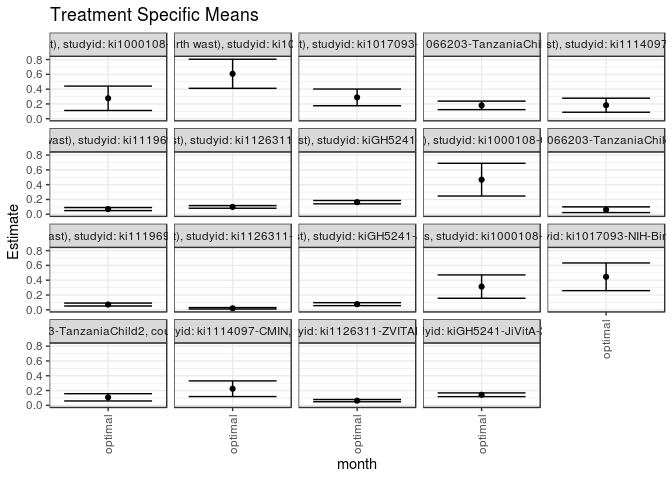

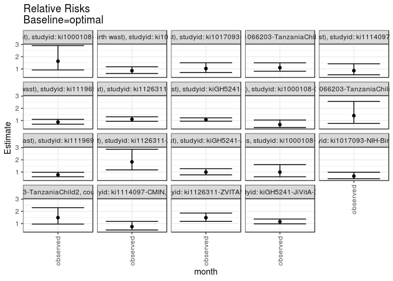

## Results Table

### Parameter: TSM

| agecat | studyid | country | intervention_level | baseline_level | estimate | ci_lower | ci_upper |
| --- | --- | --- | --- | --- | --- | --- | --- |
| 0-24 months (no birth wast) | ki1000108-CMC-V-BCS-2002 | INDIA | optimal | NA | 0.2760383 | 0.1110227 | 0.4410539 |
| 0-24 months (no birth wast) | ki1000108-IRC | INDIA | optimal | NA | 0.6074129 | 0.4108951 | 0.8039307 |
| 0-24 months (no birth wast) | ki1017093-NIH-Birth | BANGLADESH | optimal | NA | 0.2885955 | 0.1757268 | 0.4014642 |
| 0-24 months (no birth wast) | ki1066203-TanzaniaChild2 | TANZANIA, UNITED REPUBLIC OF | optimal | NA | 0.1802864 | 0.1227703 | 0.2378025 |
| 0-24 months (no birth wast) | ki1114097-CMIN | GUINEA-BISSAU | optimal | NA | 0.1827239 | 0.0881008 | 0.2773470 |
| 0-24 months (no birth wast) | ki1119695-PROBIT | BELARUS | optimal | NA | 0.0704173 | 0.0497643 | 0.0910702 |
| 0-24 months (no birth wast) | ki1126311-ZVITAMBO | ZIMBABWE | optimal | NA | 0.0993845 | 0.0816652 | 0.1171039 |
| 0-24 months (no birth wast) | kiGH5241-JiVitA-3 | BANGLADESH | optimal | NA | 0.1635854 | 0.1409901 | 0.1861808 |
| 0-6 months (no birth wast) | ki1000108-CMC-V-BCS-2002 | INDIA | optimal | NA | 0.4673689 | 0.2461893 | 0.6885486 |
| 0-6 months (no birth wast) | ki1066203-TanzaniaChild2 | TANZANIA, UNITED REPUBLIC OF | optimal | NA | 0.0615395 | 0.0230245 | 0.1000546 |
| 0-6 months (no birth wast) | ki1119695-PROBIT | BELARUS | optimal | NA | 0.0713714 | 0.0516019 | 0.0911410 |
| 0-6 months (no birth wast) | ki1126311-ZVITAMBO | ZIMBABWE | optimal | NA | 0.0204181 | 0.0110779 | 0.0297584 |
| 0-6 months (no birth wast) | kiGH5241-JiVitA-3 | BANGLADESH | optimal | NA | 0.0763417 | 0.0561785 | 0.0965048 |
| 6-24 months | ki1000108-IRC | INDIA | optimal | NA | 0.3137330 | 0.1560129 | 0.4714531 |
| 6-24 months | ki1017093-NIH-Birth | BANGLADESH | optimal | NA | 0.4459905 | 0.2589793 | 0.6330017 |
| 6-24 months | ki1066203-TanzaniaChild2 | TANZANIA, UNITED REPUBLIC OF | optimal | NA | 0.1081553 | 0.0591035 | 0.1572071 |
| 6-24 months | ki1114097-CMIN | GUINEA-BISSAU | optimal | NA | 0.2243507 | 0.1185176 | 0.3301837 |
| 6-24 months | ki1126311-ZVITAMBO | ZIMBABWE | optimal | NA | 0.0635313 | 0.0484484 | 0.0786142 |
| 6-24 months | kiGH5241-JiVitA-3 | BANGLADESH | optimal | NA | 0.1430001 | 0.1180138 | 0.1679864 |

### Parameter: E(Y)

| agecat | studyid | country | intervention_level | baseline_level | estimate | ci_lower | ci_upper |
| --- | --- | --- | --- | --- | --- | --- | --- |
| 0-24 months (no birth wast) | ki1000108-CMC-V-BCS-2002 | INDIA | observed | NA | 0.4510870 | 0.4001777 | 0.5019962 |
| 0-24 months (no birth wast) | ki1000108-IRC | INDIA | observed | NA | 0.5207824 | 0.4723080 | 0.5692568 |
| 0-24 months (no birth wast) | ki1017093-NIH-Birth | BANGLADESH | observed | NA | 0.2976589 | 0.2609818 | 0.3343359 |
| 0-24 months (no birth wast) | ki1066203-TanzaniaChild2 | TANZANIA, UNITED REPUBLIC OF | observed | NA | 0.1988255 | 0.1828010 | 0.2148500 |
| 0-24 months (no birth wast) | ki1114097-CMIN | GUINEA-BISSAU | observed | NA | 0.1573333 | 0.1389008 | 0.1757659 |
| 0-24 months (no birth wast) | ki1119695-PROBIT | BELARUS | observed | NA | 0.0612597 | 0.0474556 | 0.0750638 |
| 0-24 months (no birth wast) | ki1126311-ZVITAMBO | ZIMBABWE | observed | NA | 0.1091275 | 0.1036470 | 0.1146079 |
| 0-24 months (no birth wast) | kiGH5241-JiVitA-3 | BANGLADESH | observed | NA | 0.1741737 | 0.1663519 | 0.1819955 |
| 0-6 months (no birth wast) | ki1000108-CMC-V-BCS-2002 | INDIA | observed | NA | 0.3085714 | 0.2601110 | 0.3570318 |
| 0-6 months (no birth wast) | ki1066203-TanzaniaChild2 | TANZANIA, UNITED REPUBLIC OF | observed | NA | 0.0858586 | 0.0745914 | 0.0971258 |
| 0-6 months (no birth wast) | ki1119695-PROBIT | BELARUS | observed | NA | 0.0550194 | 0.0412334 | 0.0688054 |
| 0-6 months (no birth wast) | ki1126311-ZVITAMBO | ZIMBABWE | observed | NA | 0.0373807 | 0.0339019 | 0.0408595 |
| 0-6 months (no birth wast) | kiGH5241-JiVitA-3 | BANGLADESH | observed | NA | 0.0753350 | 0.0700333 | 0.0806367 |
| 6-24 months | ki1000108-IRC | INDIA | observed | NA | 0.3097561 | 0.2649438 | 0.3545684 |
| 6-24 months | ki1017093-NIH-Birth | BANGLADESH | observed | NA | 0.2939002 | 0.2554778 | 0.3323226 |
| 6-24 months | ki1066203-TanzaniaChild2 | TANZANIA, UNITED REPUBLIC OF | observed | NA | 0.1605550 | 0.1445335 | 0.1765765 |
| 6-24 months | ki1114097-CMIN | GUINEA-BISSAU | observed | NA | 0.1666667 | 0.1476863 | 0.1856470 |
| 6-24 months | ki1126311-ZVITAMBO | ZIMBABWE | observed | NA | 0.0939843 | 0.0884477 | 0.0995208 |
| 6-24 months | kiGH5241-JiVitA-3 | BANGLADESH | observed | NA | 0.1651666 | 0.1559963 | 0.1743368 |

### Parameter: RR

| agecat | studyid | country | intervention_level | baseline_level | estimate | ci_lower | ci_upper |
| --- | --- | --- | --- | --- | --- | --- | --- |
| 0-24 months (no birth wast) | ki1000108-CMC-V-BCS-2002 | INDIA | observed | optimal | 1.6341463 | 0.9150731 | 2.9182743 |
| 0-24 months (no birth wast) | ki1000108-IRC | INDIA | observed | optimal | 0.8573779 | 0.6249393 | 1.1762693 |
| 0-24 months (no birth wast) | ki1017093-NIH-Birth | BANGLADESH | observed | optimal | 1.0314050 | 0.7082950 | 1.5019114 |
| 0-24 months (no birth wast) | ki1066203-TanzaniaChild2 | TANZANIA, UNITED REPUBLIC OF | observed | optimal | 1.1028315 | 0.8116681 | 1.4984416 |
| 0-24 months (no birth wast) | ki1114097-CMIN | GUINEA-BISSAU | observed | optimal | 0.8610440 | 0.5210990 | 1.4227562 |
| 0-24 months (no birth wast) | ki1119695-PROBIT | BELARUS | observed | optimal | 0.8699530 | 0.6931059 | 1.0919228 |
| 0-24 months (no birth wast) | ki1126311-ZVITAMBO | ZIMBABWE | observed | optimal | 1.0980325 | 0.9255579 | 1.3026471 |
| 0-24 months (no birth wast) | kiGH5241-JiVitA-3 | BANGLADESH | observed | optimal | 1.0647262 | 0.9355587 | 1.2117272 |
| 0-6 months (no birth wast) | ki1000108-CMC-V-BCS-2002 | INDIA | observed | optimal | 0.6602309 | 0.4210164 | 1.0353633 |
| 0-6 months (no birth wast) | ki1066203-TanzaniaChild2 | TANZANIA, UNITED REPUBLIC OF | observed | optimal | 1.3951774 | 0.7591867 | 2.5639543 |
| 0-6 months (no birth wast) | ki1119695-PROBIT | BELARUS | observed | optimal | 0.7708885 | 0.6111811 | 0.9723289 |
| 0-6 months (no birth wast) | ki1126311-ZVITAMBO | ZIMBABWE | observed | optimal | 1.8307607 | 1.1702244 | 2.8641384 |
| 0-6 months (no birth wast) | kiGH5241-JiVitA-3 | BANGLADESH | observed | optimal | 0.9868136 | 0.7658670 | 1.2715014 |
| 6-24 months | ki1000108-IRC | INDIA | observed | optimal | 0.9873239 | 0.6078582 | 1.6036773 |
| 6-24 months | ki1017093-NIH-Birth | BANGLADESH | observed | optimal | 0.6589830 | 0.4440560 | 0.9779368 |
| 6-24 months | ki1066203-TanzaniaChild2 | TANZANIA, UNITED REPUBLIC OF | observed | optimal | 1.4844856 | 0.9553247 | 2.3067522 |
| 6-24 months | ki1114097-CMIN | GUINEA-BISSAU | observed | optimal | 0.7428846 | 0.4698653 | 1.1745441 |
| 6-24 months | ki1126311-ZVITAMBO | ZIMBABWE | observed | optimal | 1.4793384 | 1.1760196 | 1.8608891 |
| 6-24 months | kiGH5241-JiVitA-3 | BANGLADESH | observed | optimal | 1.1550103 | 0.9731154 | 1.3709050 |

### Parameter: PAR

| agecat | studyid | country | intervention_level | baseline_level | estimate | ci_lower | ci_upper |
| --- | --- | --- | --- | --- | --- | --- | --- |
| 0-24 months (no birth wast) | ki1000108-CMC-V-BCS-2002 | INDIA | optimal | NA | 0.1750487 | 0.0150269 | 0.3350704 |
| 0-24 months (no birth wast) | ki1000108-IRC | INDIA | optimal | NA | -0.0866305 | -0.2783318 | 0.1050708 |
| 0-24 months (no birth wast) | ki1017093-NIH-Birth | BANGLADESH | optimal | NA | 0.0090633 | -0.0994431 | 0.1175698 |
| 0-24 months (no birth wast) | ki1066203-TanzaniaChild2 | TANZANIA, UNITED REPUBLIC OF | optimal | NA | 0.0185391 | -0.0367072 | 0.0737855 |
| 0-24 months (no birth wast) | ki1114097-CMIN | GUINEA-BISSAU | optimal | NA | -0.0253906 | -0.1172601 | 0.0664789 |
| 0-24 months (no birth wast) | ki1119695-PROBIT | BELARUS | optimal | NA | -0.0091576 | -0.0249617 | 0.0066466 |
| 0-24 months (no birth wast) | ki1126311-ZVITAMBO | ZIMBABWE | optimal | NA | 0.0097429 | -0.0072449 | 0.0267308 |
| 0-24 months (no birth wast) | kiGH5241-JiVitA-3 | BANGLADESH | optimal | NA | 0.0105883 | -0.0105597 | 0.0317362 |
| 0-6 months (no birth wast) | ki1000108-CMC-V-BCS-2002 | INDIA | optimal | NA | -0.1587975 | -0.3699996 | 0.0524046 |
| 0-6 months (no birth wast) | ki1066203-TanzaniaChild2 | TANZANIA, UNITED REPUBLIC OF | optimal | NA | 0.0243190 | -0.0131822 | 0.0618203 |
| 0-6 months (no birth wast) | ki1119695-PROBIT | BELARUS | optimal | NA | -0.0163520 | -0.0319946 | -0.0007094 |
| 0-6 months (no birth wast) | ki1126311-ZVITAMBO | ZIMBABWE | optimal | NA | 0.0169626 | 0.0076952 | 0.0262300 |
| 0-6 months (no birth wast) | kiGH5241-JiVitA-3 | BANGLADESH | optimal | NA | -0.0010067 | -0.0203584 | 0.0183451 |
| 6-24 months | ki1000108-IRC | INDIA | optimal | NA | -0.0039769 | -0.1561420 | 0.1481881 |
| 6-24 months | ki1017093-NIH-Birth | BANGLADESH | optimal | NA | -0.1520903 | -0.3298192 | 0.0256386 |
| 6-24 months | ki1066203-TanzaniaChild2 | TANZANIA, UNITED REPUBLIC OF | optimal | NA | 0.0523997 | 0.0045278 | 0.1002716 |
| 6-24 months | ki1114097-CMIN | GUINEA-BISSAU | optimal | NA | -0.0576840 | -0.1606493 | 0.0452813 |
| 6-24 months | ki1126311-ZVITAMBO | ZIMBABWE | optimal | NA | 0.0304530 | 0.0157811 | 0.0451249 |
| 6-24 months | kiGH5241-JiVitA-3 | BANGLADESH | optimal | NA | 0.0221665 | -0.0024927 | 0.0468257 |

### Parameter: PAF

| agecat | studyid | country | intervention_level | baseline_level | estimate | ci_lower | ci_upper |
| --- | --- | --- | --- | --- | --- | --- | --- |
| 0-24 months (no birth wast) | ki1000108-CMC-V-BCS-2002 | INDIA | optimal | NA | 0.3880597 | -0.0928089 | 0.6573317 |
| 0-24 months (no birth wast) | ki1000108-IRC | INDIA | optimal | NA | -0.1663468 | -0.6001555 | 0.1498546 |
| 0-24 months (no birth wast) | ki1017093-NIH-Birth | BANGLADESH | optimal | NA | 0.0304488 | -0.4118411 | 0.3341818 |
| 0-24 months (no birth wast) | ki1066203-TanzaniaChild2 | TANZANIA, UNITED REPUBLIC OF | optimal | NA | 0.0932431 | -0.2320307 | 0.3326400 |
| 0-24 months (no birth wast) | ki1114097-CMIN | GUINEA-BISSAU | optimal | NA | -0.1613808 | -0.9190211 | 0.2971389 |
| 0-24 months (no birth wast) | ki1119695-PROBIT | BELARUS | optimal | NA | -0.1494874 | -0.4427809 | 0.0841844 |
| 0-24 months (no birth wast) | ki1126311-ZVITAMBO | ZIMBABWE | optimal | NA | 0.0892801 | -0.0804294 | 0.2323324 |
| 0-24 months (no birth wast) | kiGH5241-JiVitA-3 | BANGLADESH | optimal | NA | 0.0607914 | -0.0688800 | 0.1747317 |
| 0-6 months (no birth wast) | ki1000108-CMC-V-BCS-2002 | INDIA | optimal | NA | -0.5146215 | -1.3752046 | 0.0341555 |
| 0-6 months (no birth wast) | ki1066203-TanzaniaChild2 | TANZANIA, UNITED REPUBLIC OF | optimal | NA | 0.2832453 | -0.3171991 | 0.6099774 |
| 0-6 months (no birth wast) | ki1119695-PROBIT | BELARUS | optimal | NA | -0.2972045 | -0.6361763 | -0.0284586 |
| 0-6 months (no birth wast) | ki1126311-ZVITAMBO | ZIMBABWE | optimal | NA | 0.4537790 | 0.1454631 | 0.6508549 |
| 0-6 months (no birth wast) | kiGH5241-JiVitA-3 | BANGLADESH | optimal | NA | -0.0133627 | -0.3057097 | 0.2135282 |
| 6-24 months | ki1000108-IRC | INDIA | optimal | NA | -0.0128389 | -0.6451205 | 0.3764331 |
| 6-24 months | ki1017093-NIH-Birth | BANGLADESH | optimal | NA | -0.5174897 | -1.2519685 | -0.0225610 |
| 6-24 months | ki1066203-TanzaniaChild2 | TANZANIA, UNITED REPUBLIC OF | optimal | NA | 0.3263660 | -0.0467645 | 0.5664901 |
| 6-24 months | ki1114097-CMIN | GUINEA-BISSAU | optimal | NA | -0.3461041 | -1.1282693 | 0.1486058 |
| 6-24 months | ki1126311-ZVITAMBO | ZIMBABWE | optimal | NA | 0.3240221 | 0.1496740 | 0.4626225 |
| 6-24 months | kiGH5241-JiVitA-3 | BANGLADESH | optimal | NA | 0.1342069 | -0.0276273 | 0.2705549 |